# Antigua AGRRA 2025

Molly Wilson

2025-08-01

# Setup

```r
# Install packages
library(tidyverse)
library(here) # for accessing files within directory
library(readxl) # for reading indv. sheets within excel files
library(janitor) # for cleaning variable names so they have consistent capitalization etc.
# Define settings
knitr::opts_chunk$set(message = FALSE, warning = FALSE)

# Define functions
se <- function(x) sd(x, na.rm = TRUE) / sqrt(sum(!is.na(x)))
```

# Benthic

Notes + questions:

- Appears no algal height data in 2017?
- 2017 coral species data - where to get from benthic surveys, not just coral surveys? Or were species not given then?
- How to access/integrate coral recruit data?

## Point cover

Data overview:

- 2017: “BenthicPointCoverScaledByTransect.xlsx” (scaled to not include non-reef substrate)
- 2025: “BenthicCoverScaledByTransect.xlsx”

### Import + wrangle data

```r
benthic_cover_2017 <- read_excel(here("agrra_monitoring", "data_raw", "ATG_NEMMA_2017", "BenthicPointCoverScaled", "BenthicPointCoverScaledByTransect.xlsx"), sheet = "Data") %>%
  clean_names() %>%
  select(site, transect = trans, lc, cca, ta, tas, fma, cyan, ainv, pey = peys) %>%
  mutate(year = "2017",
         ta = ta + tas) %>% # to be compatible with 2025 data that aggregates TA and TAS into TA
  select(-tas)

benthic_cover_2025 <- read_excel(here("agrra_monitoring", "data_raw", "ATG_NEMMA_2025", "Calculated", "BenthicCoverScaledByTransect.xlsx"), sheet = "Overall") %>%
  clean_names() %>%
  select(site = survey_name, transect = transect_name, t_coral, t_cca, t_ta, t_fma, t_cyan, t_ainv, t_pey) %>%
  mutate(across(contains("t_"), ~ . * 100)) %>%
  mutate(year = "2025",
         site = if_else(site == "Little Bird Patch", "Little Bird Backreef", site)) %>%
  rename_with(~ gsub("^t_", "", .x)) %>%
  rename(lc = coral)

benthic_cover_trans <- bind_rows(benthic_cover_2017, benthic_cover_2025) %>%
  filter(site != "Cades Reef Outside East") # currently excluding as we have no historical data

benthic_cover_site <- benthic_cover_trans %>%
  group_by(site, year) %>%
  summarise(across(c(lc, cca, ta, fma, cyan, ainv, pey),
                   list(mean = ~ mean(.x, na.rm = TRUE),
                        se   = ~ se(.x)),
                   .names = "{.col}_{.fn}"))

benthic_cover_year <- benthic_cover_site %>%
  select(!contains("_se")) %>%
  rename_with(~ str_remove(.x, "_mean")) %>%
  group_by(year) %>%
  summarise(across(c(lc, cca, ta, fma, cyan, ainv, pey),
                   list(mean = ~ mean(.x, na.rm = TRUE),
                        se   = ~ se(.x)),
                   .names = "{.col}_{.fn}"))
```

### Line plots

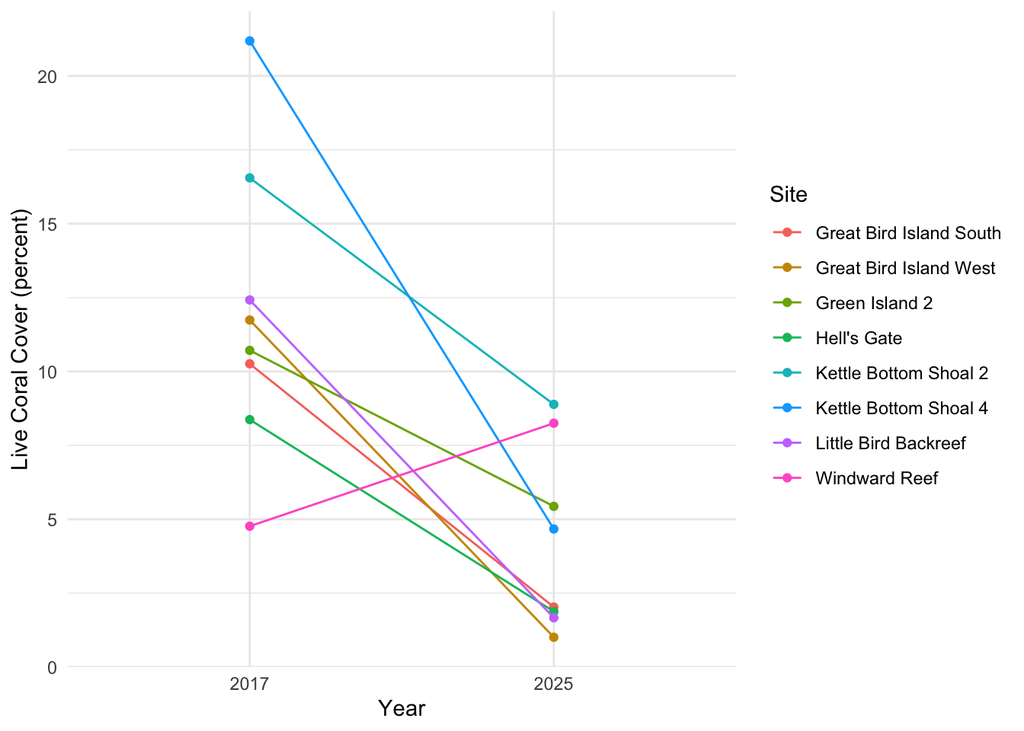

```r
ggplot(benthic_cover_site, aes(x = year, y = lc_mean, group = site, color = site)) +
  geom_point() +
  geom_line() +
  labs(x = "Year", y = "Live Coral Cover (percent)", color = "Site", group = "Site") +
  theme_minimal()
```

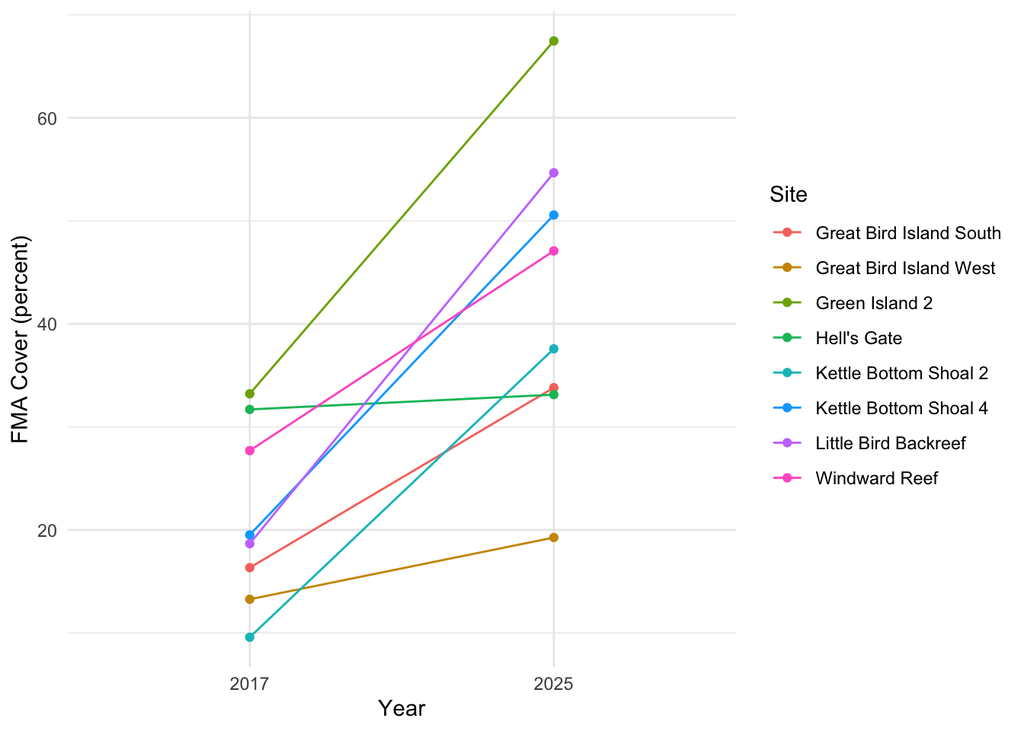

```r
ggplot(benthic_cover_site, aes(x = year, y = fma_mean, group = site, color = site)) +
  geom_point() +
  geom_line() +
  labs(x = "Year", y = "FMA Cover (percent)", color = "Site", group = "Site") +
  theme_minimal()
```

### Radar plots

Having issues adding the legend within an rmarkdown script, but red is 2017 and blue is 2025

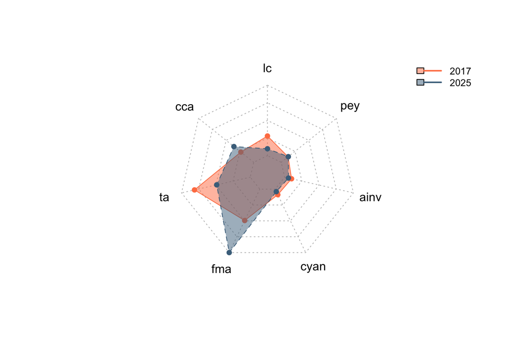

```r
library(fmsb)

max_pc <- benthic_cover_year %>%
  select(contains("_mean")) %>%
  summarise(val = max(across(), na.rm = TRUE)) %>%
  pull(val)
ncol_pc <- ncol(benthic_cover_year %>%
  select(contains("_mean")))


benthic_rdr <-
  rbind(rep(max_pc, ncol_pc),
        rep(0, ncol_pc),
        benthic_cover_year %>%
          column_to_rownames(var = "year") %>%
          select(contains("_mean")) %>%
          rename_with(~ gsub("_mean", "", .x))
        )

line_colors <- c("coral", "skyblue4")
fill_colors <- alpha(line_colors, 0.5)

radarchart(benthic_rdr,
           pcol = line_colors,
           pfcol = fill_colors,
           cglcol = "grey")

# doesn't like adding legend within rmarkdown - but can try within knit document
legend(
  x = "topright",
  legend = rownames(benthic_rdr)[3:4],  # skip max/min rows
  col = line_colors,
  lty = 1,
  lwd = 2,
  bty = "n",                   # no box
  cex = 0.8,
  pt.cex = 1.5,
  fill = fill_colors            # show fill colors in legend
)
```